# Assignment 2

```
“For even the very wise cannot see all ends.”
-J.R.R. Tolkien, The Fellowship of the Ring
```

## Libraries

#### IMPORTANT NOTES:

- Moving forward, we'll be using `ETSModel` from `statsmodels.tsa.exponential_smoothing.ets`.
- Use the `display` function from `IPython.display` for printing pandas dataframes.

```python
import numpy as np
import pandas as pd
import seaborn as sns
import matplotlib.pyplot as plt
from pandas.plotting import register_matplotlib_converters
from IPython.display import display
from tsa_functions import *

register_matplotlib_converters()
sns.set_style('darkgrid')

np.set_printoptions(precision=4)
pd.set_option('precision', 4)

import statsmodels.api as sm
from statsmodels.tsa.exponential_smoothing.ets import ETSModel
```

## Forecasting Australian Domestic Tourism

For this homework, we'll be continuing our exploration of forecasting hierarchical and grouped time series following [FPP3](https://otexts.com/fpp3/hierarchical.html).

Load the Australian domestic tourism dataset and perform the following:

- Recode the `State` variable, similar to what we did in the discussion notebook.
- Create a hierarchical time series with overnight trips in regions at the bottom level of the hierarchy (which can then be aggregated to states, then aggregated to the national `Total`), similar to what we did in the discussion notebook.
- Re-index the series using `pd.period_range` instead of the strings in `Quarter`.

Withhold the last two years (8 quarters) as a test set for evaluation. Use the rest for training.

```python
# Read dataset
df = pd.read_csv('./special_datasets/tourism.csv')
df.head()
```

|  | Quarter | Region | State | Purpose | Trips |
| --- | --- | --- | --- | --- | --- |
| 0 | 1998-01-01 | Adelaide | South Australia | Business | 135.0777 |
| 1 | 1998-04-01 | Adelaide | South Australia | Business | 109.9873 |
| 2 | 1998-07-01 | Adelaide | South Australia | Business | 166.0347 |
| 3 | 1998-10-01 | Adelaide | South Australia | Business | 127.1605 |
| 4 | 1999-01-01 | Adelaide | South Australia | Business | 137.4485 |

```python
df['State'] = df.State.replace({
    'New South Wales': 'NSW',
    'Northern Territory': 'NT',
    'Queensland': 'QLD',
    'South Australia': 'SA',
    'Tasmania': 'TAS',
    'Victoria': 'VIC',
    'Western Australia': 'WA'})
```

```python
df.head()
```

|  | Quarter | Region | State | Purpose | Trips |
| --- | --- | --- | --- | --- | --- |
| 0 | 1998-01-01 | Adelaide | SA | Business | 135.0777 |
| 1 | 1998-04-01 | Adelaide | SA | Business | 109.9873 |
| 2 | 1998-07-01 | Adelaide | SA | Business | 166.0347 |
| 3 | 1998-10-01 | Adelaide | SA | Business | 127.1605 |
| 4 | 1999-01-01 | Adelaide | SA | Business | 137.4485 |

```python
df_agg = (df.groupby(by=['Quarter', 'State', 'Region'], as_index=False)
          .agg(func=np.sum))
df_agg_pivot = df_agg.pivot_table(index='Quarter', columns=['State','Region'],
                                  values='Trips', aggfunc=np.sum,
                                  margins=True).iloc[:-1, :-1]

# reindex
df_agg_pivot.index = pd.period_range(start='1998Q1', periods=80, freq='Q')
df_agg_pivot = df_agg_pivot.sort_index()

# split from pivot
test_size = 8
df_train = df_agg_pivot.iloc[:-test_size]
df_test = df_agg_pivot.iloc[-test_size::]
```

### Q.

Suppose we wanted to use a bottom-up (BU) approach to forecast this hierarchical time series.

How many time series do we need to forecast?

```python
len(set(df.Region))
```

```
76
```

### Answer.

A bottom-up approach will be based on the bottom-level which in this case are the regions. There will be *76 models* corresponding to the number of unique regions in the data.

### Q.

What is an `ETS(A,A,A)` model?

### Answer.

The ETS(A,A,A) model is a state space time series model where all three componenets of a series (residual, trend, and seasonal components) undergo an additive temporal change.

### Q.

Using a bottom-up (BU) approach, generate 8-step forecasts using an `ETS(A,A,A)` model for all series.

Calculate the `RMSE`, `MAE`, and `MASE` metrics at each level (i.e. `Total`, `State`, `Region`).

Print the metrics as a dataframe. (For `Region`, no need to show the all the rows.)

```python
# metric dataframe
df_acc = pd.DataFrame(index=['RMSE','MAE','MASE'], columns=['Total']
                      + sorted(set(df['State']))
                      + sorted(set(df['Region'])))

# init df_forecasts
df_forecasts = pd.DataFrame(columns=df_test.columns, index=df_test.index)

h = 8 # forecast horizon

#
init_state=df_train.columns[0][0]

counter = 0
for i, tup in enumerate(df_train.columns):
    counter += 1
    state, region = tup

    curr_train = df_train[state][region]
    curr_test = df_test[state][region]

    model = ETSModel(curr_train,
                     error='add', trend='add', seasonal='add',
                     seasonal_periods = 4)

    model_fitted = model.fit(optimized=True)
    forecasts = model_fitted.forecast(h)
    df_forecasts.loc[:, (state, region)] = forecasts

    # record per region perf
    df_acc.loc['RMSE', region] = rmse(curr_test, forecasts)
    df_acc.loc['MAE', region] = mae(curr_test, forecasts)
    df_acc.loc['MASE', region] = mase(curr_test, forecasts, curr_train.values)

    # record per state perf for states other than initial state
    if (state != init_state) | (i + 1 == len(df_train.columns)):
        agg_fcast = df_forecasts.sum(axis=1, level=0)[init_state]
        agg_train = df_train.sum(axis=1, level=0)[init_state]
        agg_test = df_test.sum(axis=1, level=0)[init_state]

        # Record performance
        df_acc.loc['RMSE', init_state] = rmse(agg_test, agg_fcast)
        df_acc.loc['MAE', init_state] = mae(agg_test, agg_fcast)
        df_acc.loc['MASE', init_state] = mase(agg_test, agg_fcast, agg_train.values)

    # Record as previous State
    init_state = state

print("Confirm model count: ", counter)

# total perf
agg_fcast = df_forecasts.sum(axis=1)
agg_train = df_train.sum(axis=1)
agg_test = df_test.sum(axis=1)

# record total perf
df_acc.loc['RMSE','Total'] = rmse(agg_test, agg_fcast)
df_acc.loc['MAE','Total'] = mae(agg_test, agg_fcast)
df_acc.loc['MASE','Total'] = mase(agg_test, agg_fcast, agg_train.values)

# display results
display(df_acc.T[:20])
```

```
Confirm model count:  76
```

|  | RMSE | MAE | MASE |
| --- | --- | --- | --- |
| Total | 1888 | 1732 | 1.559 |
| ACT | 49.77 | 40.25 | 0.6273 |
| NSW | 647.2 | 569.6 | 1.275 |
| NT | 83.54 | 59.64 | 0.367 |
| QLD | 446 | 364.9 | 0.9622 |
| SA | 114.3 | 98.91 | 0.586 |
| TAS | 126.2 | 115.5 | 0.4913 |
| VIC | 885.9 | 787.2 | 1.204 |
| WA | 316 | 293.2 | 2.506 |
| Adelaide | 23.52 | 16.35 | 0.2694 |
| Adelaide Hills | 19.18 | 15.26 | 1.314 |
| Alice Springs | 21.4 | 16.14 | 0.5923 |
| Australia's Coral Coast | 78.77 | 70.41 | 2.205 |
| Australia's Golden Outback | 28.99 | 22.63 | 0.7916 |
| Australia's North West | 137.7 | 125 | 2.411 |
| Australia's South West | 75.89 | 61.36 | 0.5907 |
| Ballarat | 53.85 | 46.89 | 1.652 |
| Barkly | 14.25 | 10.48 | 1.016 |
| Barossa | 11.05 | 8.675 | 0.4977 |
| Bendigo Loddon | 30.54 | 21.4 | 0.5728 |

```python
# save BU forecasts for later comparison
df_acc_BU = df_acc.copy().T
df_forecasts_BU = df_forecasts.copy()
```

### Q.

Using a top-down (TD) approach with `average historical proportions`, generate 8-step forecasts using an `ETS(A,A,A)` model.

Calculate the `RMSE`, `MAE`, and `MASE` metrics at each level (i.e. `Total`, `State`, `Region`).

Print the metrics as a dataframe. (For `Region`, no need to show the all the rows.)

```python
# metric dataframe
df_acc = pd.DataFrame(index=['RMSE','MAE','MASE'], columns=['Total']
                      + sorted(set(df['State']))
                      + sorted(set(df['Region'])))

# init df_forecasts
df_forecasts = pd.DataFrame(index=df_test.index)

# Fit model to Total
model = ETSModel(df_train.sum(axis=1),
                 error='add', trend='add', seasonal='add',
                 seasonal_periods = 4)

model_fitted = model.fit(optimized=True)

# record total forecast
forecasts = model_fitted.forecast(h)
df_forecasts.loc[:,'Total'] = forecasts

# record perf
agg_train = df_train.sum(axis=1)
agg_fcast = forecasts
agg_test = df_test.sum(axis=1)

df_acc.loc['RMSE','Total'] = rmse(agg_test, agg_fcast)
df_acc.loc['MAE','Total'] = mae(agg_test, agg_fcast)
df_acc.loc['MASE','Total'] = mase(agg_test, agg_fcast, agg_train.values)


# per state forecasts
for state in df_train.sum(axis=1, level=0):

    p_total_state = np.mean(df_train.sum(axis=1, level=0)[state]
                            /df_train.sum(axis=1))
    df_forecasts[state] = df_forecasts['Total'] * p_total_state

    # log perf
    agg_train = df_train.sum(axis=1, level=0)[state]
    agg_fcast = df_forecasts[state]
    agg_test = df_test.sum(axis=1, level=0)[state]
    df_acc.loc['RMSE',state] = rmse(agg_test, agg_fcast)
    df_acc.loc['MAE',state] = mae(agg_test, agg_fcast)
    df_acc.loc['MASE',state] = mase(agg_test, agg_fcast, agg_train.values)


# per region forecasts
for state, region in df_train.columns:
    p_state_region = np.mean(df_train.sum(axis=1,level=1)[region]
                             /df_train.sum(axis=1, level=0)[state])
    df_forecasts[region] = df_forecasts[state] * p_state_region

    # log perf
    agg_train = df_train.sum(axis=1, level=1)[region]
    agg_fcast = df_forecasts[region]
    agg_test = df_test.sum(axis=1, level=1)[region]
    df_acc.loc['RMSE',region] = rmse(agg_test, agg_fcast)
    df_acc.loc['MAE',region] = mae(agg_test, agg_fcast)
    df_acc.loc['MASE',region] = mase(agg_test, agg_fcast, agg_train.values)

# display results
display(df_acc.T[:20])
```

|  | RMSE | MAE | MASE |
| --- | --- | --- | --- |
| Total | 609.3 | 539.7 | 0.4857 |
| ACT | 59.38 | 40.35 | 0.6289 |
| NSW | 396.2 | 339.7 | 0.7605 |
| NT | 161.9 | 142.9 | 0.8791 |
| QLD | 522.9 | 459.7 | 1.212 |
| SA | 132.7 | 113.5 | 0.6725 |
| TAS | 162.9 | 132.8 | 0.565 |
| VIC | 597.5 | 468.1 | 0.7159 |
| WA | 411.7 | 389.9 | 3.333 |
| Adelaide | 25.32 | 19.36 | 0.319 |
| Adelaide Hills | 18.56 | 15.2 | 1.308 |
| Alice Springs | 30.12 | 26.12 | 0.9581 |
| Australia's Coral Coast | 46.47 | 40.5 | 1.268 |
| Australia's Golden Outback | 56.43 | 47.81 | 1.672 |
| Australia's North West | 137.9 | 120 | 2.315 |
| Australia's South West | 186.7 | 152.4 | 1.467 |
| Ballarat | 33.26 | 29.7 | 1.047 |
| Barkly | 11.72 | 8.951 | 0.8678 |
| Barossa | 14.48 | 13.25 | 0.7601 |
| Bendigo Loddon | 22.56 | 18.67 | 0.4996 |

```python
# save TD forecasts for later comparison
df_acc_TD = df_acc.copy().T
df_forecasts_TD = df_forecasts.copy()
```

### Q.

Plot your forecasts for the `State` and `Total` levels together with the training (starting from 2011) and test observations.

This should be plotted as a 3x3 subplot (similar to the discussion notebook) with the following colors:

- `tab:blue` for training observations
- `tab:green` for test observations
- `tab:orange` for BU forecasts
- `tab:red` for TD forecasts

See Figure 11.12 in [FPP3](https://otexts.com/fpp3/tourism.html) for an idea of what your output should look like.

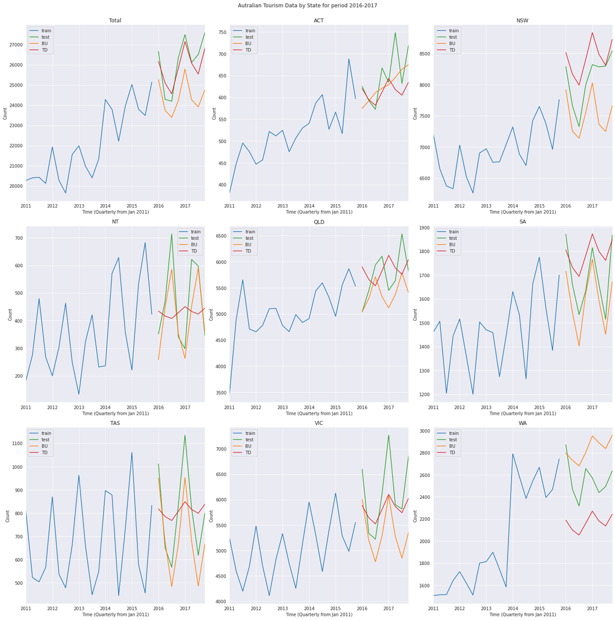

```python
fig, axes = plt.subplots(nrows=3, ncols=3, figsize=(20,20))

states = sorted(set(df['State']))

df_train[52::].sum(axis=1).plot(color='tab:blue', label='train', ax=axes[0,0])
df_test.sum(axis=1).plot(color='tab:green', label='test', ax=axes[0,0])
df_forecasts_BU.sum(axis=1).plot(color='tab:orange', label='BU', ax=axes[0,0])
df_forecasts_TD['Total'].plot(color='tab:red', label='TD', ax=axes[0,0])
axes[0,0].set_title('Total')
axes[0,0].legend()
axes[0,0].set_xlabel('Time (Quarterly from Jan 2011)')
axes[0,0].set_ylabel('Count')

for i, ax in enumerate(axes.flat[1:]):
    df_train[52::].sum(axis=1,level=0)[states[i]].plot(color='tab:blue', label='train', ax=ax)
    df_test.sum(axis=1,level=0)[states[i]].plot(color='tab:green', label='test', ax=ax)
    df_forecasts_BU.sum(axis=1,level=0)[states[i]].plot(color='tab:orange', label='BU', ax=ax)
    df_forecasts_TD[states[i]].plot(color='tab:red', label='TD', ax=ax)
    ax.set_title(states[i])
    ax.legend()
    ax.set_xlabel('Time (Quarterly from Jan 2011)')
    ax.set_ylabel('Count')

fig.suptitle('Autralian Tourism Data by State for period 2016-2017', y=1.0)
plt.subplots_adjust(hspace=0.25)
plt.tight_layout()
plt.show()
```

### Q. Post Mortem

Which strategy is better? BU or TD?

How would you quantitatively evaluate which strategy performed better? (This is NOT a trivial question. I suggest you do research.)

### Answer.

It depends on which one we are forecasting. Citing [(Athanasopoulos, Ahmed, & Hyndman, 2009)](https://robjhyndman.com/publications/hierarchical-tourism/), FPP3 sites that "Because historical proportions used for disaggregation do not take account of how those proportions may change over time, top-down approaches based on historical proportions tend to produce less accurate forecasts at lower levels of the hierarchy than bottom-up approaches." Following this logic may imply that when forecasting higher levels using the bottom-up approaches, errors at each level add up, resulting to greater error at higher levels.

For this problem we can observe by comparing the errors shown below that the top-down approach performed better when forecasting the total aggregated data. While it generally loses to the bottom-up approach on the *per state* forecasting. Shown are the proportions where the top-down approaches had greater errors than the bottom-up approach at each level. Further, code below shows that at the `Total`, the top-down approach had less errors on all three metrics than the bottom-up.

```python
# region
(df_acc_TD[9:] > df_acc_BU[9:]).sum()/len(set(df.Region))
```

```
RMSE    0.6447
MAE     0.6579
MASE    0.6579
dtype: float64
```

```python
# state
(df_acc_TD[1:9] > df_acc_BU[1:9]).sum()/len(set(df.State))
```

```
RMSE    0.75
MAE     0.75
MASE    0.75
dtype: float64
```

```python
# total
df_acc_TD.iloc[0] > df_acc_BU.iloc[0]
```

```
RMSE    False
MAE     False
MASE    False
Name: Total, dtype: bool
```